# Reproducible Research: Peer Assessment 1

## Imputing missing values

Code to describe and show a strategy for imputing missing data

Calculate and report the total number of missing values in the dataset (i.e. the total number of rows with NAs

```r
library(mice)
```

```r
#This shows how many observations have missing values.
md.pattern(data, plot = FALSE)
```

```
##       date interval steps
## 15264    1        1     1    0
## 2304     1        1     0    1
##          0        0  2304 2304
```

There are 15264 observations with no missing values and 2304 observations that are missing only the steps value.

```r
library(VIM)
```

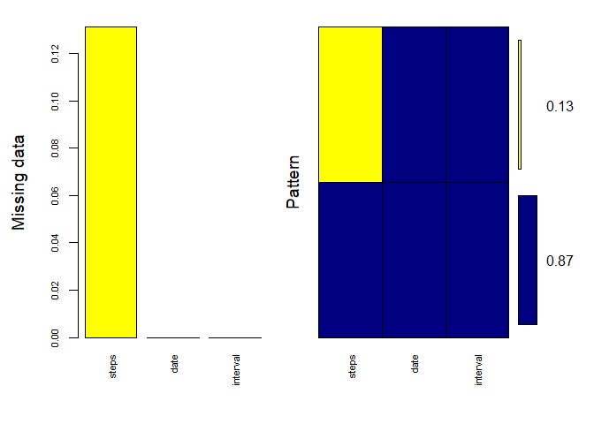

```
##
##  Variables sorted by number of missings:
##  Variable     Count
##     steps 0.1311475
##      date 0.0000000
##  interval 0.0000000
```

```r
#Graphical representation of the missing values.
mice_plot <- aggr(data, col=c('navyblue','yellow'),
                    numbers=TRUE, sortVars=TRUE,
                    labels=names(data), cex.axis=.7,
                    gap=3, ylab=c("Missing data","Pattern"))
```

```r
#impute missing data using predictive mean matching
imputed_Data <- mice(data, m=5)
summary(imputed_Data)
```

```
## Class: mids
## Number of multiple imputations:  5
## Imputation methods:
##    steps     date interval
##    "pmm"       ""       ""
## PredictorMatrix:
##          steps date interval
## steps        0    1        1
## date         1    0        1
## interval     1    1        0
```

```r
#Create a new dataset that is equal to the original dataset but with the missing data filled in.
completeData <- complete(imputed_Data,2)
```

This shows that all the missing data is in the steps variable (13% missing). The other variables did not have any missing data.

Make a histogram of the total number of steps taken each day and Calculate and report the mean and median total number of steps taken per day. Do these values differ from the estimates from the first part of the assignment? What is the impact of imputing missing data on the estimates of the total daily number of steps?

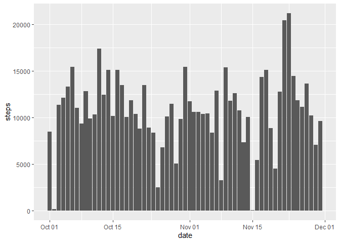

```r
#plot
ggplot(completeData,aes(date,steps))+geom_col()
```

```r
#steps per day calc
totalsteps_updated <- tapply(completeData$steps, completeData$date, FUN = sum)
steps_day_updated <- as.data.frame(totalsteps_updated)
head(steps_day_updated)
```

```
##            totalsteps_updated
## 2012-10-01               8445
## 2012-10-02                126
## 2012-10-03              11352
## 2012-10-04              12116
## 2012-10-05              13294
## 2012-10-06              15420
```

```r
steps_day_updated <-rownames_to_column(steps_day_updated,var = "date")
head(steps_day_updated)
```

```
##         date totalsteps_updated
## 1 2012-10-01               8445
## 2 2012-10-02                126
## 3 2012-10-03              11352
## 4 2012-10-04              12116
## 5 2012-10-05              13294
## 6 2012-10-06              15420
```

```r
summary(steps_day_updated$totalsteps)
```

```
##    Min. 1st Qu.  Median    Mean 3rd Qu.    Max.
##      41    8918   10600   10776   12883   21194
```

```r
mean_steps_updated <- round(mean(steps_day_updated$totalsteps), digits = 2)
mean_steps_updated
```

```
## [1] 10775.57
```

```r
med_steps_updated <- median(steps_day_updated$totalsteps)
med_steps_updated
```

```
## [1] 10600
```

## Are there differences in activity patterns between weekdays and weekends?

Panel plot comparing the average number of steps taken per 5-minute interval across weekdays and weekends

```r
library(timeDate)
data$day <- isWeekday(data$date,wday = 1:5)
library(car)
data$day[data$day=="TRUE"]<-"Weekday"
data$day[data$day=="FALSE"]<-"Weekend"

dfWeekday <- data[which(data$day == "Weekday"),]
dfWeekdayIntLevel <- aggregate(steps~interval, data = dfWeekday, FUN = function(dfWeekday) c(mean=mean(dfWeekday)))
dfWeekdayIntLevel$daytype <- "Weekday"
dfWeekend <- data[which(data$day == "Weekend"),]
dfWeekendIntLevel <- aggregate(steps~interval, data = dfWeekend, FUN = function(dfWeekend) c(mean=mean(dfWeekend)))
dfWeekendIntLevel$daytype <- "Weekend"

library(gridExtra)
```

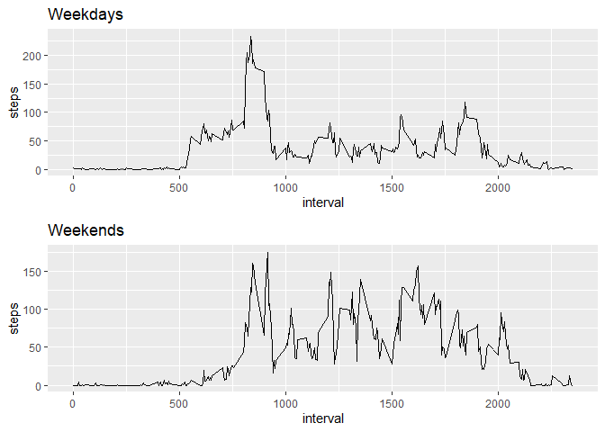

```r
plot1 <- ggplot(dfWeekdayIntLevel, aes(x=interval,y=steps))+ geom_line() + ggtitle("Weekdays")
plot2 <- ggplot(dfWeekendIntLevel, aes(x=interval,y=steps),main="Weekends")+ geom_line() + ggtitle("Weekends")
grid.arrange(plot1, plot2, nrow=2)
```

We can also look at the lines on the same graph to more easily compare.

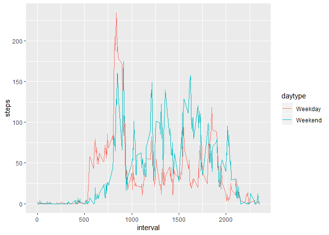

```r
#merge datasets horizontally
total <- rbind(dfWeekdayIntLevel, dfWeekendIntLevel)
#plot by day type
ggplot(total, aes(x=interval,y=steps,group=daytype,colour=daytype))+ geom_line()
```

This graph shows that people tended to have more steps in the morning on weekdays and more steps in the afternoon/evening on the weekend. Overall, the average number of steps on the weekend was 43.078373 and the average number of steps on the weekday was 35.337963.